# HW4_SVM_xz2735

Xiaofan Zhang(xz2735)

3/23/2019

### Problem 1

#### 1.

$d^2(x,x')=||x-x'||^2_2 = <x-x',x-x'> = \sqrt{(x-x')^T(x-x')} = <x,x>-2<x,x'>+<x',x'>$

#### 2.

Given $K(x,x') = <\phi(x),\phi(x')>$, the distance is $d^2_k(x,x') = ||\phi(x)-\phi(x')||^2_2 = <\phi(x)-\phi(x'),\phi(x)-\phi(x')> = \sqrt{(\phi(x)-\phi(x'))^T(\phi(x)-\phi(x'))}=<\phi(x),\phi(x)>-2<\phi(x),\phi(x')>+<\phi(x'),\phi(x')> = K(x,x)-2K(x,x')+K(x',x')$

#### 3.

It calculates the kernel distance between point x and x’.

### Problem 2

#### 1.

```r
#Load data
library(leaps)
library(tidyverse)
credit = read.csv("Credit.csv")
```

```r
#Define Dummy variables.
credit$Gender = ifelse(credit$Gender == "Female",1,0) %>% as.factor
credit$Student = ifelse(credit$Student == "Yes",1,0) %>% as.factor
credit$African.American = ifelse(credit$Ethnicity == "African American",1,0) %>% as.factor
credit$Asian = ifelse(credit$Ethnicity == "Asian",1,0)%>% as.factor
credit$Married = ifelse(credit$Married == "Yes",1,0)%>% as.factor
credit = subset(credit,select = -c(X,Ethnicity))
head(credit)
```

```
##    Income Limit Rating Cards Age Education Gender Student Married Balance
## 1  14.891  3606    283     2  34        11      0       0       1     333
## 2 106.025  6645    483     3  82        15      1       1       1     903
## 3 104.593  7075    514     4  71        11      0       0       0     580
## 4 148.924  9504    681     3  36        11      1       0       0     964
## 5  55.882  4897    357     2  68        16      0       0       1     331
## 6  80.180  8047    569     4  77        10      0       0       0    1151
##   African.American Asian
## 1                0     0
## 2                0     1
## 3                0     1
## 4                0     1
## 5                0     0
## 6                0     0
```

#### Best subset selection & Forward stepwise selection & Backward stepwise selection

```r
fit.best = regsubsets(Balance~.,nbest = 1, data = credit, method="exhaustive")
fit.fwd = regsubsets(Balance~.,data = credit,method="forward")
fit.bwd = regsubsets(Balance~.,data = credit, method = "backward")
sum.best = summary(fit.best)
sum.fwd = summary(fit.fwd)
sum.bwd = summary(fit.bwd)
```

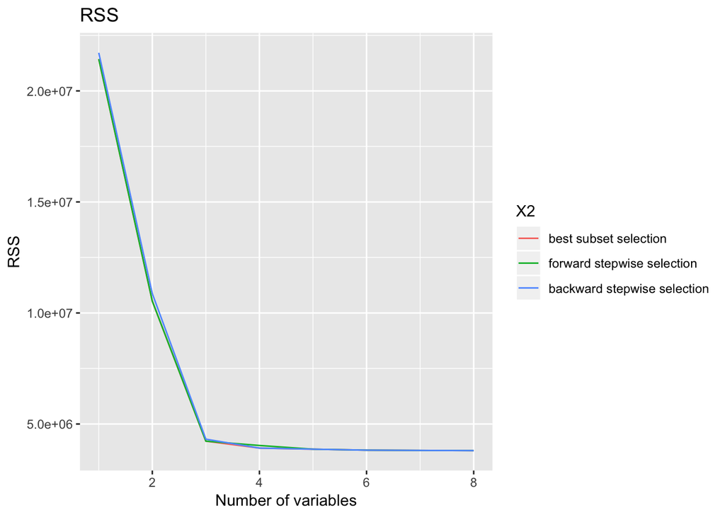

```r
library(ggplot2)
library(reshape)
rss = cbind(sum.best$rss,sum.fwd$rss,sum.bwd$rss) %>% melt
rss$X2 = recode(factor(rss$X2),'1'="best subset selection",'2'="forward stepwise selection",'3'="backward stepwise selection") %>% as.factor
ggplot(data=rss, aes(x=X1,y=value,color=X2))+
  geom_line()+
  ggtitle("RSS")+
  xlab("Number of variables")+
  ylab("RSS")
```

#### 2.

#### Best subset selection

```r
bic.min.best = which.min(sum.best$bic)
cp.min.best = which.min(sum.best$cp)
print(bic.min.best )
```

```
## [1] 4
```

```r
print(cp.min.best)
```

```
## [1] 6
```

```r
sum.best
```

```
## Subset selection object
## Call: regsubsets.formula(Balance ~ ., nbest = 1, data = credit, method = "exhaustive")
## 11 Variables  (and intercept)
##                   Forced in Forced out
## Income                FALSE      FALSE
## Limit                 FALSE      FALSE
## Rating                FALSE      FALSE
## Cards                 FALSE      FALSE
## Age                   FALSE      FALSE
## Education             FALSE      FALSE
## Gender1               FALSE      FALSE
## Student1              FALSE      FALSE
## Married1              FALSE      FALSE
## African.American1     FALSE      FALSE
## Asian1                FALSE      FALSE
## 1 subsets of each size up to 8
## Selection Algorithm: exhaustive
##          Income Limit Rating Cards Age Education Gender1 Student1 Married1
## 1  ( 1 ) " "    " "   "*"    " "   " " " "       " "     " "      " "
## 2  ( 1 ) "*"    " "   "*"    " "   " " " "       " "     " "      " "
## 3  ( 1 ) "*"    " "   "*"    " "   " " " "       " "     "*"      " "
## 4  ( 1 ) "*"    "*"   " "    "*"   " " " "       " "     "*"      " "
## 5  ( 1 ) "*"    "*"   "*"    "*"   " " " "       " "     "*"      " "
## 6  ( 1 ) "*"    "*"   "*"    "*"   "*" " "       " "     "*"      " "
## 7  ( 1 ) "*"    "*"   "*"    "*"   "*" " "       "*"     "*"      " "
## 8  ( 1 ) "*"    "*"   "*"    "*"   "*" " "       "*"     "*"      " "
##          African.American1 Asian1
## 1  ( 1 ) " "               " "
## 2  ( 1 ) " "               " "
## 3  ( 1 ) " "               " "
## 4  ( 1 ) " "               " "
## 5  ( 1 ) " "               " "
## 6  ( 1 ) " "               " "
## 7  ( 1 ) " "               " "
## 8  ( 1 ) "*"               " "
```

So for BIC, the optimal best subset model has 4 variables such that income, limit, cards, student. So for cp, the optimal best subset model has 6 variables such that income, limit, rating, cards, age student.

#### Forward stepwise selection

```r
bic.min.fwd = which.min(sum.fwd$bic)
cp.min.fwd = which.min(sum.fwd$cp)
bic.min.fwd
```

```
## [1] 5
```

```r
cp.min.fwd
```

```
## [1] 6
```

```r
sum.fwd
```

```
## Subset selection object
## Call: regsubsets.formula(Balance ~ ., data = credit, method = "forward")
## 11 Variables  (and intercept)
##                   Forced in Forced out
## Income                FALSE      FALSE
## Limit                 FALSE      FALSE
## Rating                FALSE      FALSE
## Cards                 FALSE      FALSE
## Age                   FALSE      FALSE
## Education             FALSE      FALSE
## Gender1               FALSE      FALSE
## Student1              FALSE      FALSE
## Married1              FALSE      FALSE
## African.American1     FALSE      FALSE
## Asian1                FALSE      FALSE
## 1 subsets of each size up to 8
## Selection Algorithm: forward
##          Income Limit Rating Cards Age Education Gender1 Student1 Married1
## 1  ( 1 ) " "    " "   "*"    " "   " " " "       " "     " "      " "
## 2  ( 1 ) "*"    " "   "*"    " "   " " " "       " "     " "      " "
## 3  ( 1 ) "*"    " "   "*"    " "   " " " "       " "     "*"      " "
## 4  ( 1 ) "*"    "*"   "*"    " "   " " " "       " "     "*"      " "
## 5  ( 1 ) "*"    "*"   "*"    "*"   " " " "       " "     "*"      " "
## 6  ( 1 ) "*"    "*"   "*"    "*"   "*" " "       " "     "*"      " "
## 7  ( 1 ) "*"    "*"   "*"    "*"   "*" " "       "*"     "*"      " "
## 8  ( 1 ) "*"    "*"   "*"    "*"   "*" " "       "*"     "*"      " "
##          African.American1 Asian1
## 1  ( 1 ) " "               " "
## 2  ( 1 ) " "               " "
## 3  ( 1 ) " "               " "
## 4  ( 1 ) " "               " "
## 5  ( 1 ) " "               " "
## 6  ( 1 ) " "               " "
## 7  ( 1 ) " "               " "
## 8  ( 1 ) "*"               " "
```

So for BIC, the optimal forward stepwise model has 5 variables such that income, limit, rating, cards, student. So for cp, the optimal forward stepwise model has 6 variables such that income, limit, rating, cards, age student.

#### Backward stepwise selection

```r
bic.min.bwd = which.min(sum.bwd$bic)
cp.min.bwd = which.min(sum.bwd$cp)
bic.min.bwd
```

```
## [1] 4
```

```r
cp.min.bwd
```

```
## [1] 6
```

```r
sum.bwd
```

```
## Subset selection object
## Call: regsubsets.formula(Balance ~ ., data = credit, method = "backward")
## 11 Variables  (and intercept)
##                   Forced in Forced out
## Income                FALSE      FALSE
## Limit                 FALSE      FALSE
## Rating                FALSE      FALSE
## Cards                 FALSE      FALSE
## Age                   FALSE      FALSE
## Education             FALSE      FALSE
## Gender1               FALSE      FALSE
## Student1              FALSE      FALSE
## Married1              FALSE      FALSE
## African.American1     FALSE      FALSE
## Asian1                FALSE      FALSE
## 1 subsets of each size up to 8
## Selection Algorithm: backward
##          Income Limit Rating Cards Age Education Gender1 Student1 Married1
## 1  ( 1 ) " "    "*"   " "    " "   " " " "       " "     " "      " "
## 2  ( 1 ) "*"    "*"   " "    " "   " " " "       " "     " "      " "
## 3  ( 1 ) "*"    "*"   " "    " "   " " " "       " "     "*"      " "
## 4  ( 1 ) "*"    "*"   " "    "*"   " " " "       " "     "*"      " "
## 5  ( 1 ) "*"    "*"   "*"    "*"   " " " "       " "     "*"      " "
## 6  ( 1 ) "*"    "*"   "*"    "*"   "*" " "       " "     "*"      " "
## 7  ( 1 ) "*"    "*"   "*"    "*"   "*" " "       "*"     "*"      " "
## 8  ( 1 ) "*"    "*"   "*"    "*"   "*" " "       "*"     "*"      " "
##          African.American1 Asian1
## 1  ( 1 ) " "               " "
## 2  ( 1 ) " "               " "
## 3  ( 1 ) " "               " "
## 4  ( 1 ) " "               " "
## 5  ( 1 ) " "               " "
## 6  ( 1 ) " "               " "
## 7  ( 1 ) " "               " "
## 8  ( 1 ) "*"               " "
```

So for BIC, the optimal backward stepwise model has 4 variables such that income, limit, cards, student. So for cp, the optimal backward stepwise model has 6 variables such that income, limit, rating, cards, age student.

### Problem 3

#### 1.